# ML course Project

nm

2024-10-22

## Packages and data

```r
# Load required packages
library(tidyverse)
library(caret)
library(randomForest)
library(reshape2)
```

```r
library(ggplot2)
library(rmarkdown)

#setwd
setwd("C:/Users/NickMoore/OneDrive - Integrity/Documents/ml-course/20241022_ml-course-short-version_v2_files")

# Set seed for reproducibility
set.seed(2332)

#training data
file_path_train <- "C:/Users/NickMoore/OneDrive - Integrity/Documents/ml-course/pml-training.csv"
train_data <- read.csv(file_path_train)

#testing data
file_path_test <- "C:/Users/NickMoore/OneDrive - Integrity/Documents/ml-course/pml-testing.csv"
test_data <- read.csv(file_path_test)
```

## 2. Data Cleaning and key descriptives

Columns with near-zero variance and high missing values are removed to reduce noise and irrelevant data. Descriptive analysis (bar plot of classe, boxplots of key variables, and a correlation heatmap) help understand the distribution and relationships between predictors, which gave some insight into feature importance and potential multicollinearity. Although I found this exploratory work quite hard to start and very time consuming.

```r
# Remove columns with near-zero variance
nzv_cols <- nearZeroVar(train_data)
train_data <- train_data %>% select(-all_of(nzv_cols))
test_data <- test_data %>% select(-all_of(nzv_cols))

# Remove columns with too many missing values
threshold_na <- 0.95  # Threshold for missing values
na_cols <- train_data %>%
  summarise(across(everything(), ~ mean(is.na(.)))) %>%
  pivot_longer(everything(), names_to = "feature", values_to = "na_ratio") %>%
  filter(na_ratio > threshold_na) %>%
  pull(feature)

train_data <- train_data %>% select(-all_of(na_cols))
test_data <- test_data %>% select(-all_of(na_cols))

# Remove irrelevant columns
train_data <- train_data %>%
  select(-"X",-"user_name",-"raw_timestamp_part_1",-"raw_timestamp_part_2",-"cvtd_timestamp",-"num_window")
test_data <- test_data %>%
  select(-"X",-"user_name",-"raw_timestamp_part_1",-"raw_timestamp_part_2",-"cvtd_timestamp",-"num_window")
glimpse(train_data)
```

```
## Rows: 19,622
## Columns: 53
## $ roll_belt            <dbl> 1.41, 1.41, 1.42, 1.48, 1.48, 1.45, 1.42, 1.42, 1…
## $ pitch_belt           <dbl> 8.07, 8.07, 8.07, 8.05, 8.07, 8.06, 8.09, 8.13, 8…
## $ yaw_belt             <dbl> -94.4, -94.4, -94.4, -94.4, -94.4, -94.4, -94.4, …
## $ total_accel_belt     <int> 3, 3, 3, 3, 3, 3, 3, 3, 3, 3, 3, 3, 3, 3, 3, 3, 3…
## $ gyros_belt_x         <dbl> 0.00, 0.02, 0.00, 0.02, 0.02, 0.02, 0.02, 0.02, 0…
## $ gyros_belt_y         <dbl> 0.00, 0.00, 0.00, 0.00, 0.02, 0.00, 0.00, 0.00, 0…
## $ gyros_belt_z         <dbl> -0.02, -0.02, -0.02, -0.03, -0.02, -0.02, -0.02, …
## $ accel_belt_x         <int> -21, -22, -20, -22, -21, -21, -22, -22, -20, -21,…
## $ accel_belt_y         <int> 4, 4, 5, 3, 2, 4, 3, 4, 2, 4, 2, 2, 4, 4, 2, 4, 4…
## $ accel_belt_z         <int> 22, 22, 23, 21, 24, 21, 21, 21, 24, 22, 23, 23, 2…
## $ magnet_belt_x        <int> -3, -7, -2, -6, -6, 0, -4, -2, 1, -3, -5, -2, -3,…
## $ magnet_belt_y        <int> 599, 608, 600, 604, 600, 603, 599, 603, 602, 609,…
## $ magnet_belt_z        <int> -313, -311, -305, -310, -302, -312, -311, -313, -…
```

[output cut: 40 more lines]

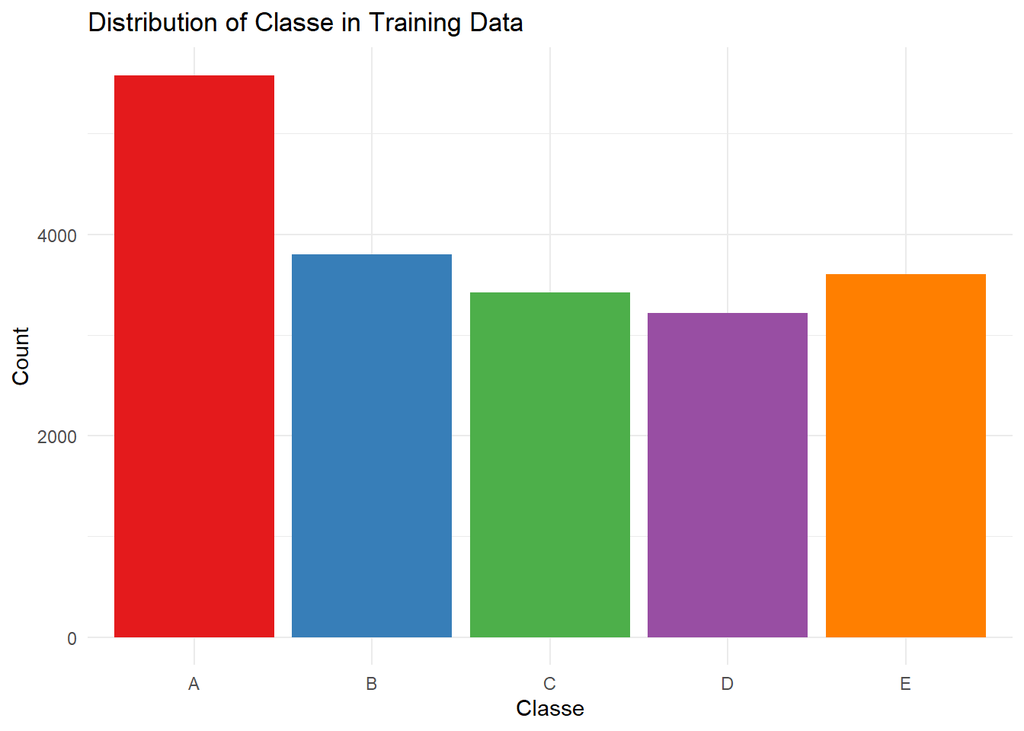

```r
# Make   'classe' is a factor var
train_data$classe <- as.factor(train_data$classe)

##descriptives

# PLto classe distr.
train_data %>%
  ggplot(aes(x = classe, fill = classe)) +
  geom_bar() +
  theme_minimal() +
  labs(title = "Distribution of Classe in Training Data",
       x = "Classe",
       y = "Count") +
  scale_fill_brewer(palette = "Set1") +
  theme(legend.position = "none")
```

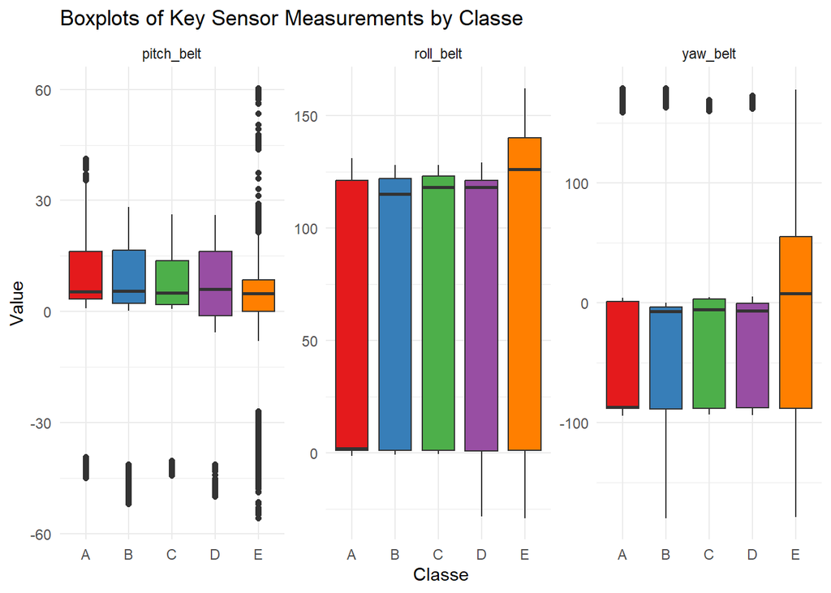

```r
key_vars <- c("roll_belt", "pitch_belt", "yaw_belt", "classe")

# Create a long-format data frame for plotting
train_long <- train_data %>%
  select(all_of(key_vars)) %>%
  pivot_longer(cols = -classe, names_to = "variable", values_to = "value")

# Plot boxplots
train_long %>%
  ggplot(aes(x = classe, y = value, fill = classe)) +
  geom_boxplot() +
  facet_wrap(~ variable, scales = "free_y") +
  theme_minimal() +
  labs(title = "Boxplots of Key Sensor Measurements by Classe",
       x = "Classe",
       y = "Value") +
  scale_fill_brewer(palette = "Set1") +
  theme(legend.position = "none")
```

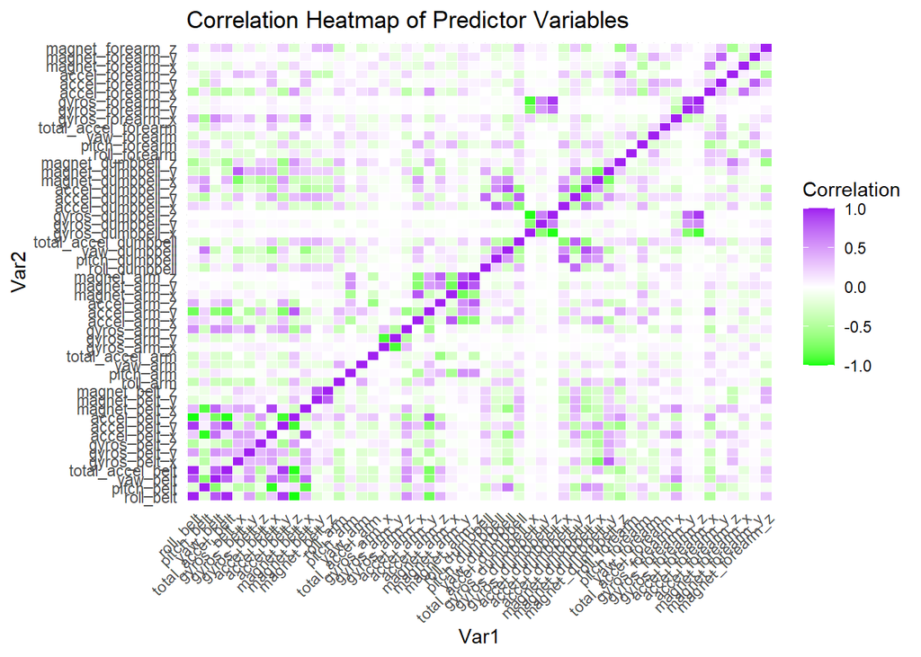

```r
# Correlation matrix of numeric predictor variables
numeric_vars <- train_data %>%
  select(where(is.numeric), -classe)

cor_matrix <- cor(numeric_vars, use = "pairwise.complete.obs")

# Melt the correlation matrix for plotting
melted_cor <- melt(cor_matrix)

# Plot the heatmap
ggplot(data = melted_cor, aes(x = Var1, y = Var2, fill = value)) +
  geom_tile(color = "white") +
  scale_fill_gradient2(low = "green", high = "purple", mid = "white",
                       midpoint = 0, limit = c(-1,1), space = "Lab",
                       name="Correlation") +
  theme_minimal() +
  labs(title = "Correlation Heatmap of Predictor Variables") +
  theme(axis.text.x = element_text(angle = 45, vjust = 1, hjust = 1))
```

## 3. Partition Training Data The training data is split into two subsets: 70% for training and 30% for testin; the model is trained on one portion and evaluated on another.

```r
train_index <- createDataPartition(train_data$classe, p = 0.7, list = FALSE)
training <- train_data[train_index, ]
testing <- train_data[-train_index, ]
```

## 4. Train Random Forest Model

A Random Forest model is trained using 5-fold cross-validation to minimise overfitting. The model is trained on 100 trees (ntree = 100) using the train function

```r
control <- trainControl(method = "cv", number = 5) # Cross-validation with 5 folds (trained on 4 parts/tested on remaining)
model_rf <- train(classe ~ ., data = training, method = "rf", trControl = control, ntree = 100)
model_rf
```

```
## Random Forest
##
## 13737 samples
##    52 predictor
##     5 classes: 'A', 'B', 'C', 'D', 'E'
##
## No pre-processing
## Resampling: Cross-Validated (5 fold)
## Summary of sample sizes: 10990, 10990, 10991, 10988, 10989
## Resampling results across tuning parameters:
##
##   mtry  Accuracy   Kappa
##    2    0.9893715  0.9865541
##   27    0.9897359  0.9870153
##   52    0.9818742  0.9770663
##
## Accuracy was used to select the optimal model using the largest value.
## The final value used for the model was mtry = 27.
```

## 5. Evaluate Model on Testing Set

The model is used to make predictions on the testing data. My view is that performs pretty well against key measures, especially accuracy and kappa.

```r
predictions <- predict(model_rf, newdata = testing)
confusion <- confusionMatrix(predictions, testing$classe)
print(confusion)
```

```
## Confusion Matrix and Statistics
##
##           Reference
## Prediction    A    B    C    D    E
##          A 1674   15    0    0    0
##          B    0 1123    0    0    0
##          C    0    1 1021    9    3
##          D    0    0    5  954    2
##          E    0    0    0    1 1077
##
## Overall Statistics
##
##                Accuracy : 0.9939
##                  95% CI : (0.9915, 0.9957)
##     No Information Rate : 0.2845
##     P-Value [Acc > NIR] : < 2.2e-16
##
##                   Kappa : 0.9923
##
##  Mcnemar's Test P-Value : NA
##
## Statistics by Class:
##
##                      Class: A Class: B Class: C Class: D Class: E
## Sensitivity            1.0000   0.9860   0.9951   0.9896   0.9954
## Specificity            0.9964   1.0000   0.9973   0.9986   0.9998
## Pos Pred Value         0.9911   1.0000   0.9874   0.9927   0.9991
## Neg Pred Value         1.0000   0.9966   0.9990   0.9980   0.9990
## Prevalence             0.2845   0.1935   0.1743   0.1638   0.1839
## Detection Rate         0.2845   0.1908   0.1735   0.1621   0.1830
## Detection Prevalence   0.2870   0.1908   0.1757   0.1633   0.1832
## Balanced Accuracy      0.9982   0.9930   0.9962   0.9941   0.9976
```

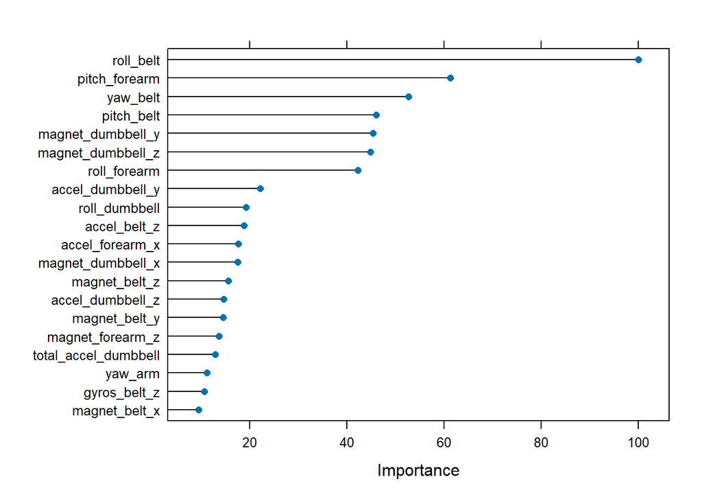

```r
#good accuracy and Kappa, sensitivity and specificity

importance <- varImp(model_rf)
plot(importance, top = 20)
```

## 6. Calculate Out-of-Sample Error A low error rate, such as 0.61%, suggests the model is highly accurate.But I guess error rate is context dependent. Whats fine here might not be ok elsewhere. Exercise performance might have a bearing on health outcomes so could be something to look at?

```r
accuracy <- confusion$overall['Accuracy']
out_of_sample_error <- 1 - accuracy
print(paste("Out-of-sample error:", round(out_of_sample_error, 4)))
```

```
## [1] "Out-of-sample error: 0.0061"
```

```r
# this is good for this type of application but note the links to health/exercise may mean it isnt - its not my field
```

## 7. Predict on Final Test Set

The model is applied to the test set.I got stuck fora while because I forgot to remove classe from the test_data.

```r
#remember that classe is removed heree!
final_predictions <- predict(model_rf, newdata = test_data) # n=20 in test_data
```

## 8. Output Predictions

Final predictions for evaluation

```r
print(final_predictions)
```

```
##  [1] B A B A A E D B A A B C B A E E A B B B
## Levels: A B C D E
```